# Introduction to prcbench

2026-09-26

The `prcbench` package is a testing workbench for evaluating precision-recall curves, which requires simple three step processes to perform evaluations of libraries that create precision-recall plots.

1. Tool selection by using the tool interface
2. Test data selection/creation by using the test data interface
   1. Select pre-defined test data for the accuracy evaluation
   2. Define randomly generated test data for the running-time evaluation
3. Run a evaluation function with the selected tools and test data sets
   1. Accuracy evaluation of precision-recall curves
   2. Running-time evaluation of precision-recall curves

In addition to predefined tools and test data sets, the `prcbench` package provides help functions for users to define their own tools and datasets.

4. User-defined tool interface
5. User-defined test data interface
   1. User-defined test data for the accuracy evaluation
   2. User-defined test data for the running-time evaluation

## 1. Tool interface

The `prcbench` package provides predefined interfaces for the following seven tools that calculate precision-recall curves.

| Tool | Language | Link |
| --- | --- | --- |
| precrec | R | [Tool web site](https://evalclass.github.io/precrec/), [CRAN](https://cran.r-project.org/package=precrec) |
| ROCR | R | [Tool web site](https://ipa-tys.github.io/ROCR/), [CRAN](https://cran.r-project.org/package=ROCR) |
| PRROC | R | [CRAN](https://cran.r-project.org/package=PRROC) |
| AUCCalculator | Java | [Tool web site](http://mark.goadrich.com/programs/AUC/) |
| PerfMeas | R | [CRAN](https://cran.r-project.org/package=PerfMeas) |
| yardstick | R | [Tool web site](https://yardstick.tidymodels.org/), [CRAN](https://cran.r-project.org/package=yardstick) |
| sklearn | Python | [Tool web site](https://scikit-learn.org/stable/modules/generated/sklearn.metrics.precision_recall_curve.html) |

The `sklearn` tool is calculated by a standalone Python module that is bundled with `prcbench` and derived from the scikit-learn source code, so scikit-learn itself is not required. Running it does require the `reticulate` package, a working Python installation and `numpy`. When they are unavailable, `sklearn` returns a flat dummy curve instead of raising an error, in the same way as `AUCCalculator` does without `rJava`, so the predefined tool sets stay usable on a machine without Python.

Timings from `run_benchmark` are not comparable between `sklearn` and the R tools. Every `sklearn` call crosses the R/Python boundary and converts the input and output vectors, and that overhead is counted as part of the measurement. On the small test sets used here it often dominates the curve calculation itself. The `sklearn` timing therefore measures the cost of the round trip to Python rather than the speed of the scikit-learn algorithm. Curve accuracy from `run_evalcurve` is unaffected, since it does not depend on how long the calculation takes.

### Create a tool set

The `create_toolset` function generates a tool set with a combination of the seven tools.

```r
library(prcbench)

## A single tool
toolsetA <- create_toolset("ROCR")

## Multiple tools
toolsetB <- create_toolset(c("PerfMeas", "PRROC"))

## Tool sets can be manually combined to a single set
toolsetAB <- c(toolsetA, toolsetB)
```

`sklearn` is a member of every predefined set, and it can also be requested by name on its own. The following example is not evaluated in this vignette, because it needs `reticulate`, Python and `numpy`.

```r
## The sklearn tool on its own
toolsetS <- create_toolset("sklearn")

## ... or combined with the R tools
toolsetRS <- create_toolset(c("precrec", "sklearn"))

## Curve evaluation works in the same way as it does for the other tools
run_evalcurve(create_testset("curve", c("c1", "c2", "c3")), toolsetRS)
```

`Toolsklearn` offers two AUC calculation methods. `aucType = 1`, the default, uses average precision, which is the summary scikit-learn recommends for precision-recall curves, whereas `aucType = 2` uses the trapezoidal rule.

```r
## Use the trapezoidal rule instead of average precision
toolsklearn <- Toolsklearn$new(aucType = 2)
```

### Arguments of the `create_toolset` function

The `create_toolset` function takes two additional arguments - `calc_auc` and `store_res`.

- `calc_auc` decides whether tools calculate AUC score or not (Calculation of AUCs are optional for the running-time evaluation, but not necessary for the evaluation of accurate precision-recall curves)
- `store_res` decides whether tools store the calculated curves or not (actual curves are required for the evaluation of accurate precision-recall curves)

### Use predefined tool sets

| Set name | Tools | calc_auc | store_res |
| --- | --- | --- | --- |
| def7 | ROCR, AUCCalculator, PerfMeas, PRROC, precrec, yardstick, sklearn | TRUE | TRUE |
| auc7 | ROCR, AUCCalculator, PerfMeas, PRROC, precrec, yardstick, sklearn | TRUE | FALSE |
| crv7 | ROCR, AUCCalculator, PerfMeas, PRROC, precrec, yardstick, sklearn | FALSE | TRUE |
| def6 | ROCR, AUCCalculator, PRROC, precrec, yardstick, sklearn | TRUE | TRUE |
| auc6 | ROCR, AUCCalculator, PRROC, precrec, yardstick, sklearn | TRUE | FALSE |
| crv6 | ROCR, AUCCalculator, PRROC, precrec, yardstick, sklearn | FALSE | TRUE |
| def5 | ROCR, PRROC, precrec, yardstick, sklearn | TRUE | TRUE |
| auc5 | ROCR, PRROC, precrec, yardstick, sklearn | TRUE | FALSE |
| crv5 | ROCR, PRROC, precrec, yardstick, sklearn | FALSE | TRUE |
| def4 | ROCR, precrec, yardstick, sklearn | TRUE | TRUE |
| auc4 | ROCR, precrec, yardstick, sklearn | TRUE | FALSE |
| crv4 | ROCR, precrec, yardstick, sklearn | FALSE | TRUE |

```r
## Use 'set_names'
toolsetC <- create_toolset(set_names = "auc7")

## Multiple sets are automatically combined to a single set
toolsetD <- create_toolset(set_names = c("auc7", "crv4"))
```

## 2. Test data interface

The `prcbench` package provides two different types of test data sets.

1. `curve`: evaluates the accuracy of precision-recall curves
2. `bench`: measures running times of creating precision-recall curves

The `create_testset` function offers both types of test data by setting the first argument either as “curve” or “bench”.

### 2a. Select pre-defined test data for the accuracy evaluation

The `create_testset` function takes predefined set names for curve evaluation. These data sets contain pre-calculated precision and recall values. The pre-calculated values must be correct so that they can be compared with the results of specified tools.

The following four test sets are currently available.

[output not shown]

```r
## C1 test set
testset2A <- create_testset("curve", "c1")

## C2 test set
testset2B <- create_testset("curve", "c2")

## Test data sets can be manually combined to a single set
testset2AB <- c(testset2A, testset2B)

## Multiple sets are automatically combined to a single set
testset2C <- create_testset("curve", c("c1", "c2"))
```

### 2b. Create randomly generated test data for the running-time evaluation

The `create_testset` function uses a naming convention for randomly generated data for benchmarking. The format is a prefix (‘b’ or ‘i’) followed by the number of dataset. The prefix ‘b’ indicates a balanced dataset, whereas ‘i’ indicates an imbalanced dataset. The number can be used with a suffix ‘k’ or ‘m’, indicating respectively 1000 or 1 million.

```r
## A balanced data set with 50 positives and 50 negatives
testset1A <- create_testset("bench", "b100")

## An imbalanced data set with 2500 positives and 7500 negatives
testset1B <- create_testset("bench", "i10k")

## Test data sets can be manually combined to a single set
testset1AB <- c(testset1A, testset1B)

## Multiple sets are automatically combined to a single set
testset1C <- create_testset("bench", c("i10", "b10"))
```

## 3. Run a evaluation function with the selected tools and test data sets

The `prcbench` package currently provides two different types of performance evaluation.

1. Accuracy evaluation of precision-recall curves
2. Running-time evaluation of precision-recall curves

### 3a. Accuracy evaluation of precision-recall curves

The `run_evalcurve` function evaluates precision-recall curves with the following five test cases. The basic idea is that the function returns the full score as long as the points generated by a library matches with the manually calculated recall and precision values.

| Test case | Description |
| --- | --- |
| fpoint | Check the first point |
| int_pts | Check the intermediate points |
| epoint | Check the end point |
| x_range | Evaluate a range between two recall values |
| y_range | Evaluate a range between two precision values |

#### Evaluation scores

The `run_evalcurve` function calculates the scores of the test cases and summarizes them to a data frame.

```r
## Evaluate precision-recall curves for ROCR and precrec with c1 test set
testset <- create_testset("curve", "c1")
toolset <- create_toolset(c("ROCR", "precrec"))
scores <- run_evalcurve(testset, toolset)
scores
```

```
##   testset toolset toolname score
## 1      c1    ROCR     ROCR   5/8
## 2      c1 precrec  precrec   8/8
```

The result of each test case can be displayed by specifying `data_type` = `all` of the `print` function.

```r
## Print all results
print(scores, data_type = "all")
```

```
##    testset toolset toolname testitem testcat success total
## 1       c1    ROCR     ROCR  x_range      Rg       1     1
## 2       c1    ROCR     ROCR  y_range      Rg       1     1
## 3       c1    ROCR     ROCR   fpoint      SE       0     1
## 4       c1    ROCR     ROCR   intpts      Ip       2     4
## 5       c1    ROCR     ROCR   epoint      SE       1     1
## 6       c1 precrec  precrec  x_range      Rg       1     1
## 7       c1 precrec  precrec  y_range      Rg       1     1
## 8       c1 precrec  precrec   fpoint      SE       1     1
## 9       c1 precrec  precrec   intpts      Ip       4     4
## 10      c1 precrec  precrec   epoint      SE       1     1
```

#### Visualization of the result

The `autoplot` shows a plot with the result of the `run_evalcurve` function.

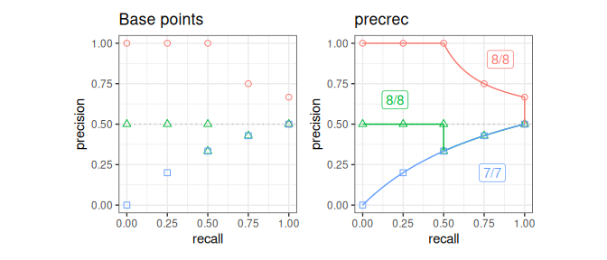

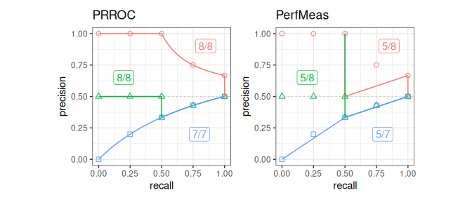

```r
## ggplot2 is necessary to use autoplot
library(ggplot2)

## Plot base points and the result of precrec on c1, c2, and c3 test sets
testset <- create_testset("curve", c("c1", "c2", "c3"))
toolset <- create_toolset("precrec")
scores1 <- run_evalcurve(testset, toolset)
autoplot(scores1)

## Plot the results of PerfMeas and PRROC on c1, c2, and c3 test sets
toolset <- create_toolset(c("PerfMeas", "PRROC"))
scores2 <- run_evalcurve(testset, toolset)
autoplot(scores2, base_plot = FALSE)
```

### 3b. Running-time evaluation of precision-recall curves

The `run_benchmark` function internally calls the `microbenchmark` function provided by the microbenchmark package. It takes a test set and a tool set and returns the result of `microbenchmark`.

```r
## Run microbenchmark for auc7 on b10
testset <- create_testset("bench", "b10")
toolset <- create_toolset(set_names = "auc7")
res <- run_benchmark(testset, toolset)
res
```

```
##   testset toolset      toolname   min    lq  mean median    uq   max neval
## 1     b10    auc7 AUCCalculator 1.605 2.063 4.093  2.349 3.475 10.97     5
## 2     b10    auc7         PRROC 0.139 0.140 0.166  0.148 0.158  0.24     5
## 3     b10    auc7      PerfMeas 0.052 0.054 0.078  0.059 0.066  0.16     5
## 4     b10    auc7          ROCR 1.537 1.580 1.701  1.581 1.736  2.07     5
## 5     b10    auc7       precrec 5.303 5.434 5.517  5.528 5.596  5.72     5
## 6     b10    auc7       sklearn 0.346 0.348 1.611  0.350 0.399  6.61     5
## 7     b10    auc7     yardstick 1.551 1.617 6.055  1.931 8.496 16.68     5
```

The `sklearn` row includes the R/Python conversion overhead described in section 1, so it should be compared with the other rows only with that caveat in mind.

## 4. Create a user-defined tool

In addition to the predefined seven tools, users can add new tool interfaces for their own tools to run benchmarking and curve evaluation. The `create_usrtool` function takes a name of the tool and a function for calculating a precision-recall curve.

```r
## Create a new tool set for 'xyz'
toolname <- "xyz"
calcfunc <- create_example_func()
toolsetU <- create_usrtool(toolname, calcfunc)

## User-defined tools can be combined with predefined tools
toolsetA <- create_toolset("ROCR")
toolsetU2 <- c(toolsetA, toolsetU)
```

Like the predefined tool sets, user-defined tool sets can be used for both `run_benchmark` and `run_evalcurve`.

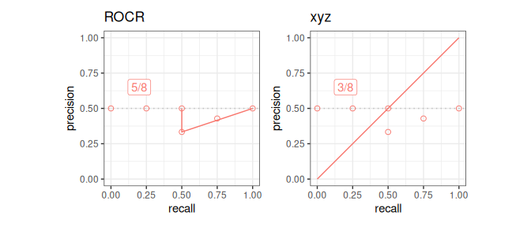

```r
## Curve evaluation
testset3 <- create_testset("curve", "c2")
scores3 <- run_evalcurve(testset3, toolsetU2)
autoplot(scores3, base_plot = FALSE)
```

### The format of the function for calculating a precision-recall curve

The `create_example_func` function creates an example for the second argument of the `create_usrtool` function. The actual function should also take a `testset` generated by the `create_testset` function and returns a list with three elements - `x`, `y`, and `auc`.

```r
## Show an example of the second argument
calcfunc <- create_example_func()
print(calcfunc)
```

```
## function (single_testset)
## {
##     scores <- single_testset$get_scores()
##     list(x = seq(0, 1, 1/length(scores)), y = seq(0, 1, 1/length(scores)),
##         auc = 0.5)
## }
## <bytecode: 0x59eb47fb62d0>
## <environment: 0x59eb464a3a70>
```

The `create_testset` function produces a `testset` as either `TestDataB` or `TestDataC` object. See the help files of the R6 classes - `help(TestDataB)` and `help(TestDataC)` - for the methods that can be used with the precision-recall calculation.

## 5. Create a user-defined test data

The `prcbench` package also supports user-defined test data interfaces. The `create_usrdata` function creates two types of test datasets.

1. User-defined test data for the accuracy evaluation
2. User-defined test data for the running-time evaluation

### 5a. User-defined test data for the accuracy evaluation

The first argument of the `create_usrdata` function should be “curve” to create a test dataset for the accuracy evaluation. Scores and labels as well as pre-calculated recall and precision values are required. These pre-calculated values are used to compare with the corresponding values predicted by the specified tools.

```r
## Create a test dataset 'c5' for benchmarking
testsetC <- create_usrdata("curve",
  scores = c(0.1, 0.2), labels = c(1, 0),
  tsname = "c5", base_x = c(0.0, 1.0),
  base_y = c(0.0, 0.5)
)
```

It can be used in the same way as the predefined test datasets selected by `create_testset`.

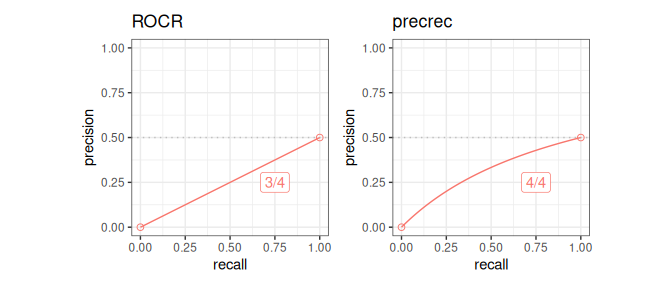

```r
## Run curve evaluation for ROCR and precrec on a predefined test dataset
toolset2 <- create_toolset(c("ROCR", "precrec"))
scores2 <- run_evalcurve(testsetC, toolset2)
autoplot(scores2, base_plot = FALSE)
```

#### 5b. User-defined test data for the running-time evaluation

The first argument of the `create_usrdata` function should be “bench” to create a test dataset for the running-time evaluation. Scores and labels are also required.

```r
## Create a test dataset 'b5' for benchmarking
testsetB <- create_usrdata("bench",
  scores = c(0.1, 0.2), labels = c(1, 0),
  tsname = "b5"
)
```

It can be used in the same way as the test datasets generated by `create_testset`.

```r
## Run microbenchmark for ROCR and precrec on a predefined test dataset
toolset <- create_toolset(c("ROCR", "precrec"))
res <- run_benchmark(testsetB, toolset)
res
```

```
##   testset toolset toolname min  lq mean median  uq max neval
## 1      b5    ROCR     ROCR 1.6 1.6  1.7    1.7 1.7 1.9     5
## 2      b5 precrec  precrec 5.2 5.5  5.6    5.6 5.7 5.9     5
```

## 6. External links

See our website, [Classifier evaluation with imbalanced datasets](https://classeval.wordpress.com/), for useful tips for performance evaluation on binary classifiers. In addition, we have summarized potential pitfalls of ROC plots with imbalanced datasets. See our paper, [The Precision-Recall Plot Is More Informative than the ROC Plot When Evaluating Binary Classifiers on Imbalanced Datasets](https://journals.plos.org/plosone/article?id=10.1371/journal.pone.0118432), for more details.